# Univariate Time Series Analysis

### Kevin Sheppard

# Seasonality

- A seasonal time series has a deterministic pattern that repeats on an annual basis

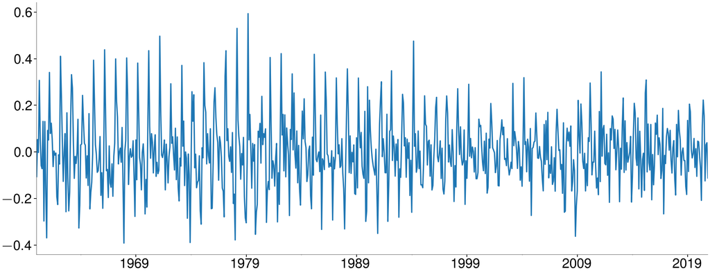

```python
plot(housing, y=-2)
```

# Seasonal Autocorrelation Pattern

- Seasonal data has dynamics at the annual frequency

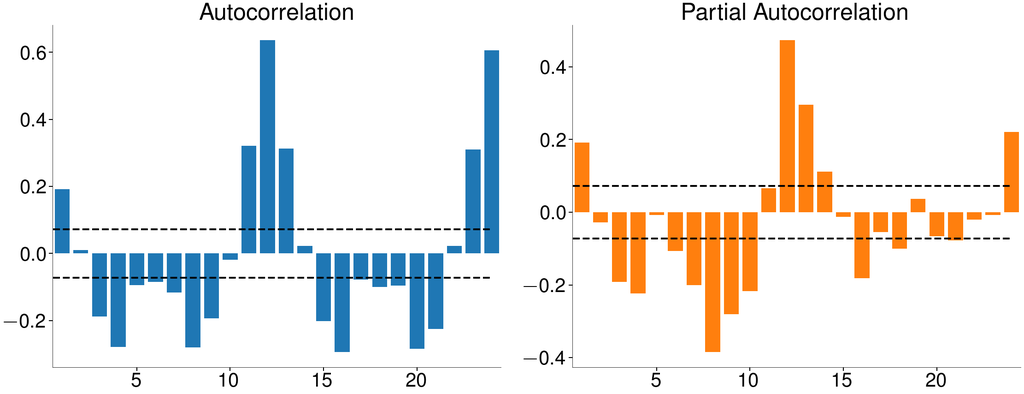

```python
acf_pacf_plot(housing, 24, size=-2)
```

# Seasonal Differencing

- Seasonal differencing differences using the seasonal period $s$

$$ \Delta_{s} Y_t = Y_t - Y_{t-s} $$

- Can reduce or eliminate seasonalities

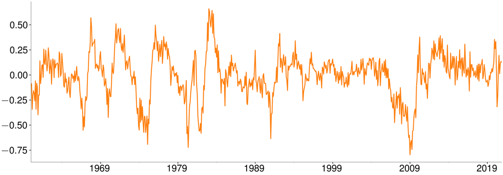

```python
plot(housing_yoy, y=12)
```

# Seasonal Difference Autocorrelation Pattern

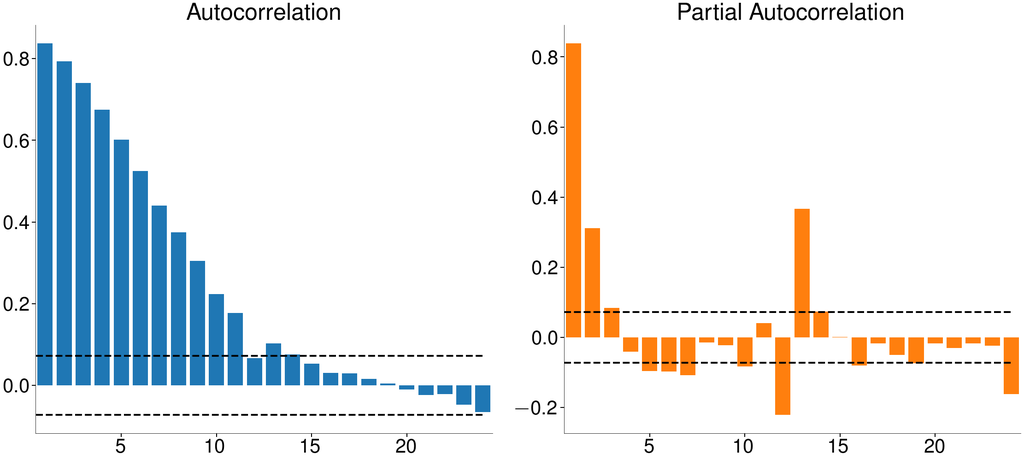

```python
acf_pacf_plot(housing_yoy, 24)
```

# Modeling Seasonal Differences

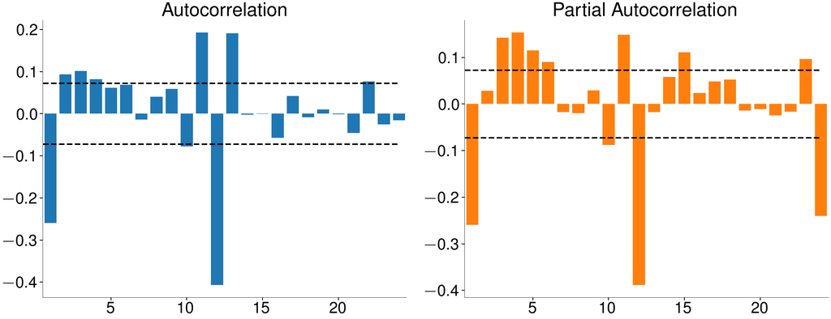

```python
res = SARIMAX(housing_yoy, order=(1, 0, 0)).fit()
resids = res.resid.iloc[1:]
acf_pacf_plot(resids, 24, size=-2)
```

# Seasonal ARMA Models

- SARMA models data at both the observational and seasonal frequency
- In lag polynomial representation

$$ (1-\phi_1 L -\phi_2 L^2) Y_t = \phi_0 + (1+\theta_s L^s)\epsilon_t $$

- In standard ARMA representation

$$ Y_t = \phi_0 + \phi_1 Y_{t-1} +\phi_2 Y_{t-2} + \theta_s \epsilon_{t-s} + \epsilon_t $$$$ \text{SARMA}(P,0,Q)\times(P_s,0,Q_s,s) $$

```python
res = SARIMAX(housing_yoy, order=(2, 0, 0), seasonal_order=(0, 0, 1, 12)).fit()
summary(res)
```

|  | coef | std err | z | P>\|z\| | [0.025 | 0.975] |
| --- | --- | --- | --- | --- | --- | --- |
| ar.L1 | 0.6809 | 0.034 | 20.284 | 0.000 | 0.615 | 0.747 |
| ar.L2 | 0.2824 | 0.034 | 8.233 | 0.000 | 0.215 | 0.350 |
| ma.S.L12 | -0.8795 | 0.017 | -50.520 | 0.000 | -0.914 | -0.845 |
| sigma2 | 0.0083 | 0.000 | 21.791 | 0.000 | 0.008 | 0.009 |

# SARMA Residual Diagnostics

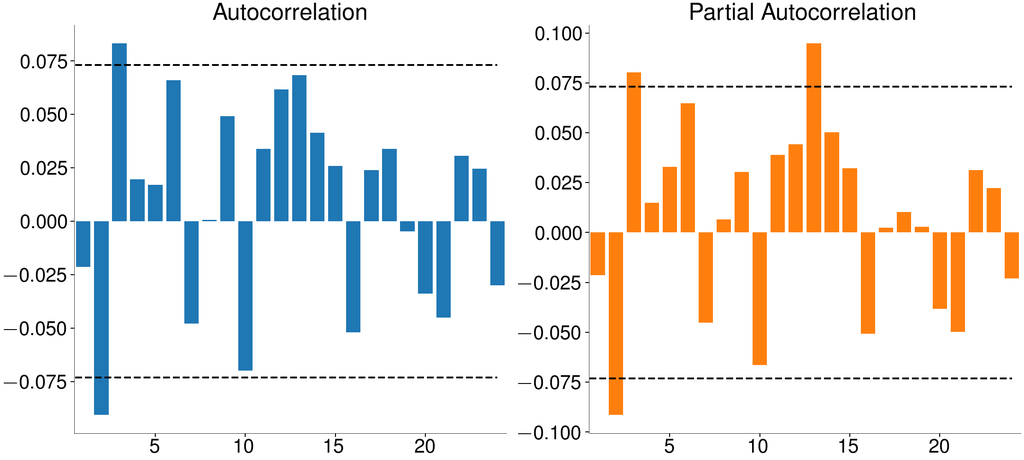

```python
acf_pacf_plot(res.resid.iloc[13:], 24)
```

# Extended Dynamics $(1,0,1)\times(1,0,1)_{12}$

- In lag polynomial representation

$$ (1-\phi_1 L)(1-\phi_s L^s)Y_t = \phi_0 + (1+\theta_1 L)(1+\theta_s L^s)\epsilon_t $$

- In standard ARMA representation

$$ Y_t = \phi_0 + \phi_1 Y_{t-1} +\phi_s Y_{t-s} - \phi_1\phi_s Y_{t-s-1} + \theta_1 \epsilon_{t-1} +\theta_s \epsilon_{t-s} + \theta_1\theta_s \epsilon_{t-s-1} + \epsilon_t $$

```python
res = SARIMAX(housing_raw, order=(1, 0, 1), seasonal_order=(1, 0, 1, 12)).fit()
summary(res)
```

|  | coef | std err | z | P>\|z\| | [0.025 | 0.975] |
| --- | --- | --- | --- | --- | --- | --- |
| ar.L1 | 0.9994 | 0.001 | 1441.218 | 0.000 | 0.998 | 1.001 |
| ma.L1 | -0.3196 | 0.031 | -10.367 | 0.000 | -0.380 | -0.259 |
| ar.S.L12 | 0.9987 | 0.001 | 1469.955 | 0.000 | 0.997 | 1.000 |
| ma.S.L12 | -0.8957 | 0.016 | -54.402 | 0.000 | -0.928 | -0.863 |
| sigma2 | 0.0083 | 0.000 | 22.277 | 0.000 | 0.008 | 0.009 |

# Extended Model Residual Diagnostics

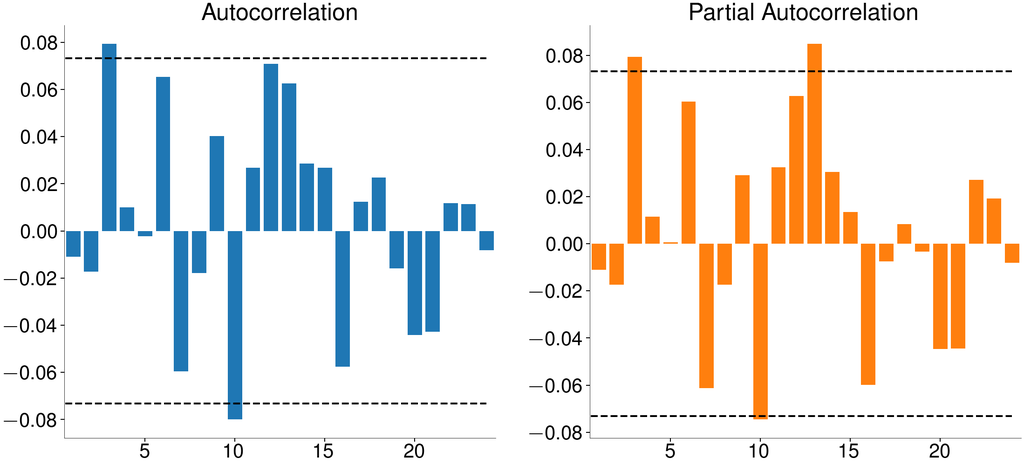

```python
acf_pacf_plot(res.resid.iloc[13:], 24)
```

# Incorporating differencing

- SARIMA - Seasonal Autoregressive Integrated Moving Average

$$ \text{SARIMA} (P,D,Q)\times(P_s,D_s,Q_s,s)$$$$ \Phi(L)\Phi_s(L)(1-L)^D(1-L^s)^{D_s} Y_t = \phi_0 + \Theta(L)\Theta_s(L)\epsilon_t $$

- **AR** $$\Phi(L) = $1-\phi_1 L - \phi_2 L^2 - \ldots -\phi_P L^P$$
- **Seasonal AR**: $$\Phi_s(L) = 1-\phi_s L^s - \phi_{2s} L^{2s} - \ldots -\phi_{P_s s} L^{P_s s}$$
- **MA**: $$\Theta(L) = 1+\theta_1 L + \theta_2 L^2 + \ldots +\theta_Q L^Q$$
- **Seasonal MA**: $$\Theta_s(L) = 1+\theta_s L^s + \theta_{2s} L^{2s} + \ldots +\theta_{Q_s s} L^{Q_s s}$$

# Estimating SARIMA Models

```python
res = SARIMAX(housing_raw, order=(1, 0, 1), seasonal_order=(0, 1, 1, 12)).fit()
summary(res)
```

|  | coef | std err | z | P>\|z\| | [0.025 | 0.975] |
| --- | --- | --- | --- | --- | --- | --- |
| ar.L1 | 0.9777 | 0.008 | 126.932 | 0.000 | 0.963 | 0.993 |
| ma.L1 | -0.3128 | 0.033 | -9.352 | 0.000 | -0.378 | -0.247 |
| ma.S.L12 | -0.8775 | 0.018 | -48.061 | 0.000 | -0.913 | -0.842 |
| sigma2 | 0.0083 | 0.000 | 21.771 | 0.000 | 0.008 | 0.009 |

# SARIMA$(1,0,1)\times(0,1,1)_{12}$ Residual Analysis

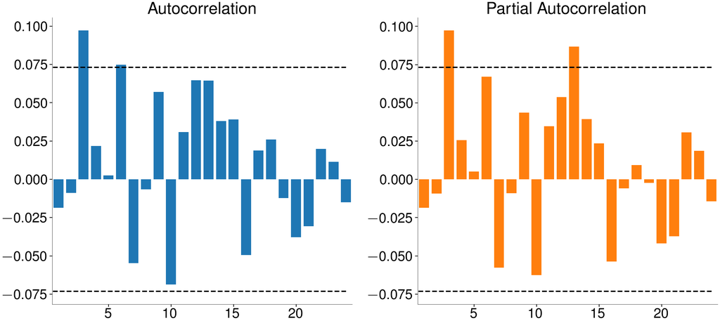

```python
acf_pacf_plot(res.resid.iloc[13:], 24)
```

# Enforcing Unit Roots

```python
res = SARIMAX(housing_raw, order=(0, 1, 1), seasonal_order=(0, 1, 1, 12)).fit()
summary(res)
```

|  | coef | std err | z | P>\|z\| | [0.025 | 0.975] |
| --- | --- | --- | --- | --- | --- | --- |
| ma.L1 | -0.3246 | 0.031 | -10.362 | 0.000 | -0.386 | -0.263 |
| ma.S.L12 | -0.8774 | 0.019 | -47.035 | 0.000 | -0.914 | -0.841 |
| sigma2 | 0.0084 | 0.000 | 22.025 | 0.000 | 0.008 | 0.009 |

# Double Difference Residual Diagnostics

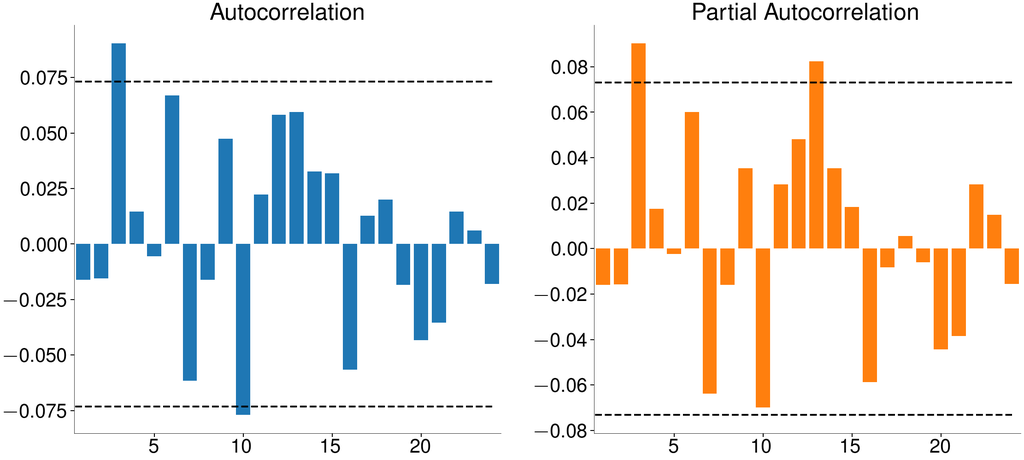

```python
acf_pacf_plot(res.resid.iloc[13:], 24)
```

# Seasonal Dummies

- Alternative approach to SARIMA
- Model shifts as a deterministic processes
- One dummy for each of $s-1$ periods
  - Avoid dummy variable trap

```python
month = housing_raw.index.strftime("%b")
dummies = pd.get_dummies(month)
dummies = dummies[
    ["Feb", "Mar", "Apr", "May", "Jun", "Jul", "Aug", "Sep", "Oct", "Nov", "Dec"]
]
dummies.index = housing_raw.index
dummies.head()
```

|  | Feb | Mar | Apr | May | Jun | Jul | Aug | Sep | Oct | Nov | Dec |
| --- | --- | --- | --- | --- | --- | --- | --- | --- | --- | --- | --- |
| 1960-01-01 | 0 | 0 | 0 | 0 | 0 | 0 | 0 | 0 | 0 | 0 | 0 |
| 1960-02-01 | 1 | 0 | 0 | 0 | 0 | 0 | 0 | 0 | 0 | 0 | 0 |
| 1960-03-01 | 0 | 1 | 0 | 0 | 0 | 0 | 0 | 0 | 0 | 0 | 0 |
| 1960-04-01 | 0 | 0 | 1 | 0 | 0 | 0 | 0 | 0 | 0 | 0 | 0 |
| 1960-05-01 | 0 | 0 | 0 | 1 | 0 | 0 | 0 | 0 | 0 | 0 | 0 |

# Incorporating Dummies

```python
res = SARIMAX(housing_raw, order=(2, 1, 0), exog=dummies, trend="c").fit()
summary(res)
```

|  | coef | std err | z | P>\|z\| | [0.025 | 0.975] |
| --- | --- | --- | --- | --- | --- | --- |
| intercept | 0.0002 | 0.004 | 0.048 | 0.962 | -0.007 | 0.008 |
| Feb | 0.0358 | 0.012 | 2.965 | 0.003 | 0.012 | 0.059 |
| Mar | 0.3075 | 0.012 | 24.777 | 0.000 | 0.283 | 0.332 |
| Apr | 0.4289 | 0.015 | 29.516 | 0.000 | 0.400 | 0.457 |
| May | 0.4669 | 0.018 | 26.260 | 0.000 | 0.432 | 0.502 |
| Jun | 0.4697 | 0.019 | 25.308 | 0.000 | 0.433 | 0.506 |
| Jul | 0.4328 | 0.019 | 23.265 | 0.000 | 0.396 | 0.469 |
| Aug | 0.4117 | 0.019 | 22.227 | 0.000 | 0.375 | 0.448 |
| Sep | 0.3657 | 0.017 | 21.802 | 0.000 | 0.333 | 0.399 |
| Oct | 0.3921 | 0.015 | 26.252 | 0.000 | 0.363 | 0.421 |
| Nov | 0.2169 | 0.013 | 16.942 | 0.000 | 0.192 | 0.242 |
| Dec | 0.0502 | 0.010 | 5.240 | 0.000 | 0.031 | 0.069 |
| ar.L1 | -0.2675 | 0.033 | -8.115 | 0.000 | -0.332 | -0.203 |
| ar.L2 | -0.1107 | 0.034 | -3.276 | 0.001 | -0.177 | -0.044 |
| sigma2 | 0.0087 | 0.000 | 21.344 | 0.000 | 0.008 | 0.010 |

# Seasonal Dummy Model Residuals

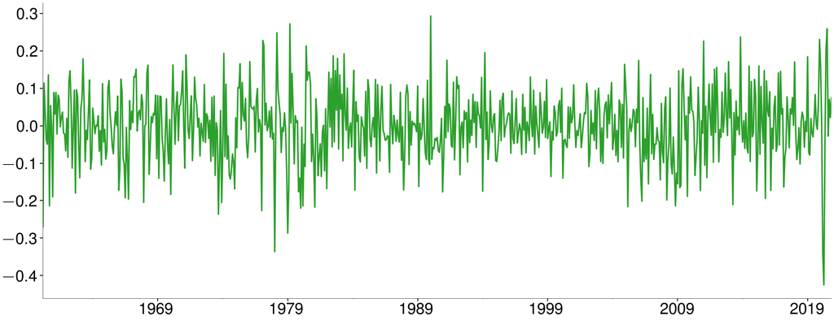

```python
resid = res.resid.iloc[2:]
plot(resid, y=-2)
```

# Seasonal Dummy Model Residuals Diagnostics

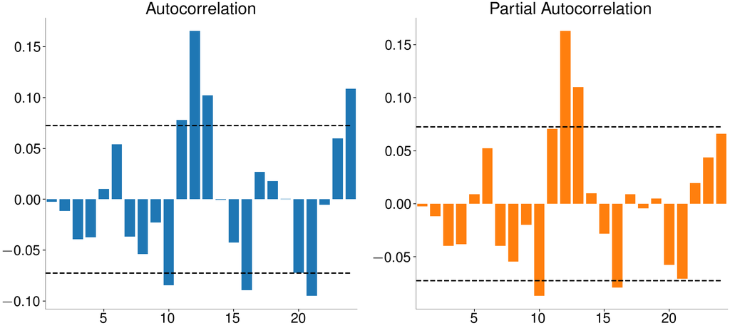

```python
acf_pacf_plot(resid, 24)
```

# Unit Root Testing

- Test $Y_t$ for a unit root
- If null is not rejected, ensure that all required deterministic terms are included
- If null is still *not* rejected, difference and test $\Delta Y_t$
- Positive $Y_t$ series should usually be transformed with $\ln$
- Select lag length of $\Delta Y_{t-j}$ terms using IC, usually AIC
- $H_0:\gamma=0$, $H_1:\gamma<0$

$$ \Delta Y_t = \delta_0 + \delta_1 t + \gamma Y_{t-1} + \sum_{i=1}^P \Delta \lambda_i Y_{t-i} + \epsilon_t $$

- Deterministic terms are needed to remove deterministic components from $Y_{t-1}$

# The Dickey-Fuller distributions

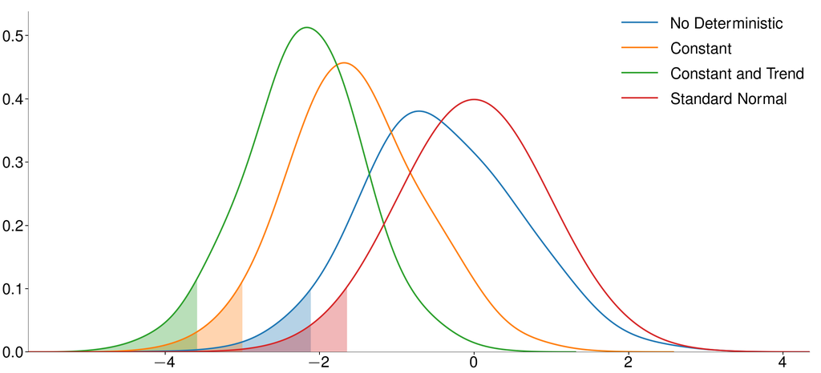

```python
adf_cv_plot()
```

# Testing Default Premium

```python
from arch.unitroot import ADF

adf = ADF(default)
adf.summary()
```

Augmented Dickey-Fuller Results

| Test Statistic | -3.866 |
| --- | --- |
| P-value | 0.002 |
| Lags | 10 |

Trend: Constant  
Critical Values: -3.44 (1%), -2.87 (5%), -2.57 (10%)  
Null Hypothesis: The process contains a unit root.  
Alternative Hypothesis: The process is weakly stationary.

# Testing Curvature

```python
adf = ADF(curve)
adf.summary()
```

Augmented Dickey-Fuller Results

| Test Statistic | -4.412 |
| --- | --- |
| P-value | 0.000 |
| Lags | 19 |

Trend: Constant  
Critical Values: -3.44 (1%), -2.87 (5%), -2.57 (10%)  
Null Hypothesis: The process contains a unit root.  
Alternative Hypothesis: The process is weakly stationary.

# Testing Industrial Production

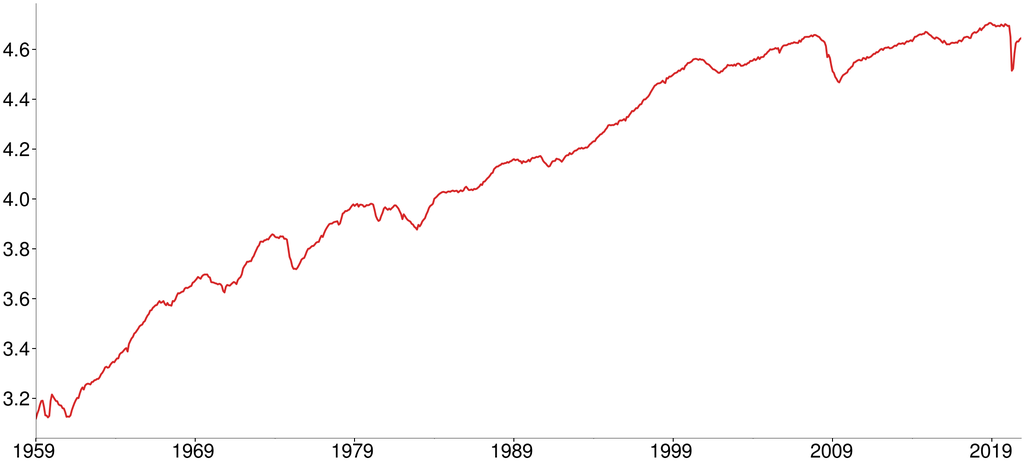

```python
plot(ln_indpro)
```

# ADF with a constant

```python
adf = ADF(ln_indpro, trend="c")
adf.summary()
```

Augmented Dickey-Fuller Results

| Test Statistic | -2.186 |
| --- | --- |
| P-value | 0.211 |
| Lags | 4 |

Trend: Constant  
Critical Values: -3.44 (1%), -2.87 (5%), -2.57 (10%)  
Null Hypothesis: The process contains a unit root.  
Alternative Hypothesis: The process is weakly stationary.

# ADF Regression Results

```python
summary(adf.regression)
```

|  | coef | std err | t | P>\|t\| | [0.025 | 0.975] |
| --- | --- | --- | --- | --- | --- | --- |
| Level.L1 | -0.0017 | 0.001 | -2.186 | 0.029 | -0.003 | -0.000 |
| Diff.L1 | 0.3637 | 0.037 | 9.860 | 0.000 | 0.291 | 0.436 |
| Diff.L2 | -0.1110 | 0.039 | -2.832 | 0.005 | -0.188 | -0.034 |
| Diff.L3 | 0.0447 | 0.039 | 1.138 | 0.255 | -0.032 | 0.122 |
| Diff.L4 | 0.0217 | 0.037 | 0.589 | 0.556 | -0.051 | 0.094 |
| const | 0.0083 | 0.003 | 2.579 | 0.010 | 0.002 | 0.015 |

# Increasing the deterministic order

```python
adf = ADF(ln_indpro, trend="ct")
adf
```

Augmented Dickey-Fuller Results

| Test Statistic | -1.831 |
| --- | --- |
| P-value | 0.690 |
| Lags | 6 |

Trend: Constant and Linear Time Trend  
Critical Values: -3.97 (1%), -3.42 (5%), -3.13 (10%)  
Null Hypothesis: The process contains a unit root.  
Alternative Hypothesis: The process is weakly stationary.

# ADF Regression Results

```python
summary(adf.regression)
```

|  | coef | std err | t | P>\|t\| | [0.025 | 0.975] |
| --- | --- | --- | --- | --- | --- | --- |
| Level.L1 | -0.0061 | 0.003 | -1.831 | 0.067 | -0.013 | 0.000 |
| Diff.L1 | 0.3680 | 0.037 | 10.010 | 0.000 | 0.296 | 0.440 |
| Diff.L2 | -0.1034 | 0.039 | -2.643 | 0.008 | -0.180 | -0.027 |
| Diff.L3 | 0.0459 | 0.039 | 1.168 | 0.243 | -0.031 | 0.123 |
| Diff.L4 | 0.0489 | 0.039 | 1.245 | 0.213 | -0.028 | 0.126 |
| Diff.L5 | -0.0571 | 0.039 | -1.455 | 0.146 | -0.134 | 0.020 |
| Diff.L6 | 0.0646 | 0.038 | 1.701 | 0.089 | -0.010 | 0.139 |
| const | 0.0231 | 0.011 | 2.053 | 0.040 | 0.001 | 0.045 |
| trend | 9.34e-06 | 7.07e-06 | 1.320 | 0.187 | -4.55e-06 | 2.32e-05 |

# Quadratic Time Trend

$$ \Delta Y_t = \delta_0 + \delta_1 t + \delta_2 t^2 + \gamma Y_{t-1} + \sum_{i=1}^P \lambda_i \Delta Y_{t-i} + \epsilon_t $$

```python
adf = ADF(ln_indpro, trend="ctt")
adf
```

Augmented Dickey-Fuller Results

| Test Statistic | -2.962 |
| --- | --- |
| P-value | 0.314 |
| Lags | 6 |

Trend: Constant, Linear and Quadratic Time Trends  
Critical Values: -4.39 (1%), -3.84 (5%), -3.56 (10%)  
Null Hypothesis: The process contains a unit root.  
Alternative Hypothesis: The process is weakly stationary.

# ADF Regression Results

```python
summary(adf.regression)
```

|  | coef | std err | t | P>\|t\| | [0.025 | 0.975] |
| --- | --- | --- | --- | --- | --- | --- |
| Level.L1 | -0.0157 | 0.005 | -2.962 | 0.003 | -0.026 | -0.005 |
| Diff.L1 | 0.3705 | 0.037 | 10.103 | 0.000 | 0.298 | 0.442 |
| Diff.L2 | -0.0987 | 0.039 | -2.527 | 0.012 | -0.175 | -0.022 |
| Diff.L3 | 0.0501 | 0.039 | 1.277 | 0.202 | -0.027 | 0.127 |
| Diff.L4 | 0.0538 | 0.039 | 1.372 | 0.170 | -0.023 | 0.131 |
| Diff.L5 | -0.0526 | 0.039 | -1.342 | 0.180 | -0.129 | 0.024 |
| Diff.L6 | 0.0713 | 0.038 | 1.878 | 0.061 | -0.003 | 0.146 |
| const | 0.0526 | 0.017 | 3.105 | 0.002 | 0.019 | 0.086 |
| trend | 5.205e-05 | 1.97e-05 | 2.644 | 0.008 | 1.34e-05 | 9.07e-05 |
| quadratic_trend | -3.109e-08 | 1.34e-08 | -2.324 | 0.020 | -5.73e-08 | -4.82e-09 |

# Testing the difference

- The Industrial Productivity Index is $I(1)$ since 1 difference makes it stationary

```python
delta_indpro = np.log(orig.INDPRO).diff().dropna()
adf = ADF(delta_indpro, trend="c")
adf
```

Augmented Dickey-Fuller Results

| Test Statistic | -11.945 |
| --- | --- |
| P-value | 0.000 |
| Lags | 3 |

Trend: Constant  
Critical Values: -3.44 (1%), -2.87 (5%), -2.57 (10%)  
Null Hypothesis: The process contains a unit root.  
Alternative Hypothesis: The process is weakly stationary.

# The importance of time trends

- Incorrect trend specification results in no power to reject false nulls
- Always find a unit root in trending time series

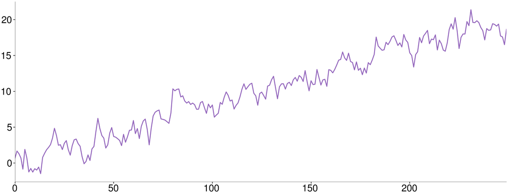

```python
plot(trending, 13)
```

# Under-specifying Deterministic Terms

- Do not use model with no deterministic terms on real data unless $Y_t$ is known to be mean 0

```python
ADF(trending, trend="n")
```

Augmented Dickey-Fuller Results

| Test Statistic | 1.934 |
| --- | --- |
| P-value | 0.988 |
| Lags | 9 |

Trend: No Trend  
Critical Values: -2.58 (1%), -1.94 (5%), -1.62 (10%)  
Null Hypothesis: The process contains a unit root.  
Alternative Hypothesis: The process is weakly stationary.

# Under-specifying Deterministic Terms

```python
ADF(trending, trend="c")
```

Augmented Dickey-Fuller Results

| Test Statistic | -1.146 |
| --- | --- |
| P-value | 0.696 |
| Lags | 9 |

Trend: Constant  
Critical Values: -3.46 (1%), -2.87 (5%), -2.57 (10%)  
Null Hypothesis: The process contains a unit root.  
Alternative Hypothesis: The process is weakly stationary.

# Correctly specifying Deterministic Terms

```python
ADF(trending, trend="ct")
```

Augmented Dickey-Fuller Results

| Test Statistic | -6.790 |
| --- | --- |
| P-value | 0.000 |
| Lags | 0 |

Trend: Constant and Linear Time Trend  
Critical Values: -4.00 (1%), -3.43 (5%), -3.14 (10%)  
Null Hypothesis: The process contains a unit root.  
Alternative Hypothesis: The process is weakly stationary.

# Over-specifying Deterministic Terms

```python
ADF(y, trend="ctt")
```

Augmented Dickey-Fuller Results

| Test Statistic | -6.885 |
| --- | --- |
| P-value | 0.000 |
| Lags | 0 |

Trend: Constant, Linear and Quadratic Time Trends  
Critical Values: -4.42 (1%), -3.86 (5%), -3.57 (10%)  
Null Hypothesis: The process contains a unit root.  
Alternative Hypothesis: The process is weakly stationary.

# Incorporating Time Trends into ARMA Models

- Can jointly estimate trends and stationary components of ARMA models

$$ Y_t = \phi_0 + \delta_1 t + \phi_1 Y_{t-1} + \epsilon_t $$

```python
res = SARIMAX(trending, order=(1, 0, 0), trend="ct").fit()
summary(res)
```

|  | coef | std err | z | P>\|z\| | [0.025 | 0.975] |
| --- | --- | --- | --- | --- | --- | --- |
| intercept | 0.0796 | 0.116 | 0.687 | 0.492 | -0.148 | 0.307 |
| drift | 0.0255 | 0.004 | 6.149 | 0.000 | 0.017 | 0.034 |
| ar.L1 | 0.6822 | 0.050 | 13.534 | 0.000 | 0.583 | 0.781 |
| sigma2 | 0.9213 | 0.080 | 11.451 | 0.000 | 0.764 | 1.079 |

# Time Trend Model Residuals

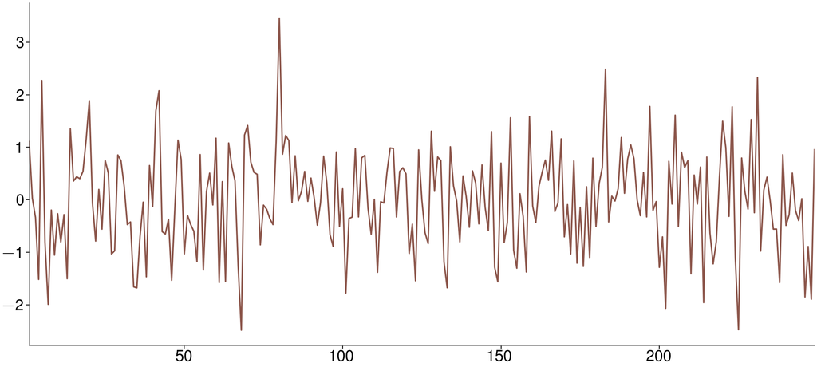

```python
plot(res.resid.iloc[1:])
```

# Next Week

- Univariate Volatility Modeling